# Reproducable Research Project 1

Frank Oelker

9 4 2021

## Commit containing full submission

1. Code for reading in the dataset and/or processing the data
2. Histogram of the total number of steps taken each day
3. Mean and median number of steps taken each day
4. Time series plot of the average number of steps taken
5. The 5-minute interval that, on average, contains the maximum number of steps
6. Code to describe and show a strategy for imputing missing data
7. Histogram of the total number of steps taken each day after missing values are imputed
8. Panel plot comparing the average number of steps taken per 5-minute interval across weekdays and weekends
9. All of the R code needed to reproduce the results (numbers, plots, etc.) in the report

## Loading and preprocessing the data

The repository includes the needed File “activity.zip”.  
This file will get unzipped into a CSV-file, if the CSV-file not exists.

```r
if(!file.exists("./activity.csv")) {
   dataSetZip <- "activity.zip"
   unzip(dataSetZip)
}
activity <- read.csv("activity.csv")
```

The dataset has to contain 17.568 observations.

```r
dim(activity)
```

```
## [1] 17568     3
```

Print some details of the dataset to check if a transformation is needed for the analysis.

```r
names(activity)
```

```
## [1] "steps"    "date"     "interval"
```

```r
head(activity)
```

```
##   steps       date interval
## 1    NA 2012-10-01        0
## 2    NA 2012-10-01        5
## 3    NA 2012-10-01       10
## 4    NA 2012-10-01       15
## 5    NA 2012-10-01       20
## 6    NA 2012-10-01       25
```

```r
str(activity)
```

```
## 'data.frame':    17568 obs. of  3 variables:
##  $ steps   : int  NA NA NA NA NA NA NA NA NA NA ...
##  $ date    : chr  "2012-10-01" "2012-10-01" "2012-10-01" "2012-10-01" ...
##  $ interval: int  0 5 10 15 20 25 30 35 40 45 ...
```

### Histogram of the total number of steps taken each day

The following histogram is a standard histogram - it can be modified by many ways but there are no instructions to do that.

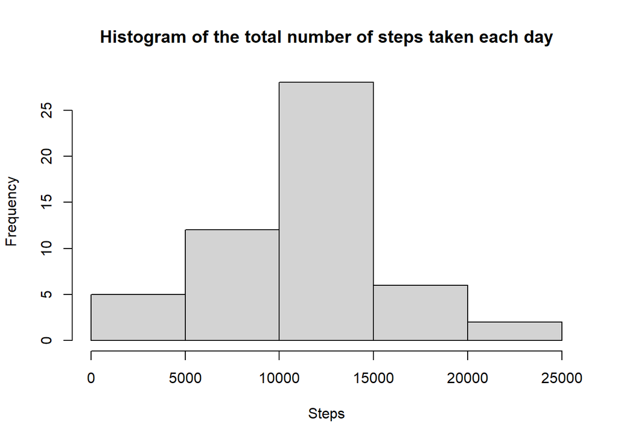

```r
spd <- tapply(activity$steps, activity$date, sum)
hist(spd, main = "Histogram of the total number of steps taken each day",
     xlab = "Steps")
```

## What is mean total number of steps taken per day?

Mean and median number of steps taken each day:

```r
mean <- mean(spd, na.rm = TRUE)
median <- median(spd, na.rm = TRUE)
```

The mean of steps taken each day is: 1.0766189^{4}  
The median of steps taken each day is: 10765

## What is the average daily activity pattern?

### Time series plot of the average number of steps taken

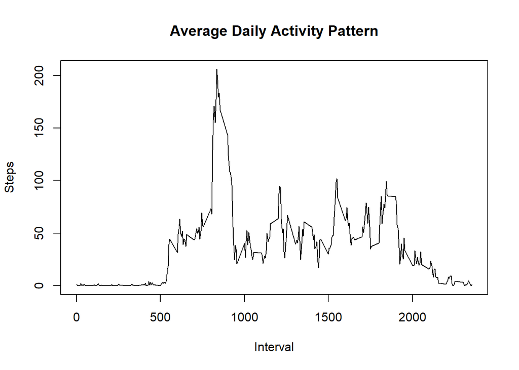

```r
step <- tapply(activity$steps, activity$interval, mean, na.rm = TRUE)
plot(as.numeric(names(step)), step, xlab = "Interval", ylab = "Steps",
     main = "Average Daily Activity Pattern", type = "l")
```

### The 5-minute interval that, on average, contains the maximum number of steps

```r
maxInterval <- names(sort(step, decreasing = TRUE)[1])
maxSteps <- sort(step, decreasing = TRUE)[1]
```

The interval 835 contains with 206.1698113 the maximum number of steps.`

## Imputing missing values

### Calculate and report the total number of missing values in the dataset.

```r
na <- sum(is.na(activity$steps))
```

There are 2304 missing values.

### Devise a strategy for filling in all of the missing values in the dataset.

The strategy does not need to be sophisticated. For example, you could use the mean/median for that daym or the mean for that 5-minute interval, etc.

The missing data is replaced with the average number of steps resulting from the available data of all days for that particular interval.

### Create a new dataset that is equal to the original dataset but with the missing data filled in.

```r
stepInterval <- tapply(activity$steps, activity$interval, mean, na.rm = TRUE)
actSplit <- split(activity, activity$interval)
for(i in 1:length(actSplit)) {
    actSplit[[i]]$steps[is.na(actSplit[[i]]$steps)] <- stepInterval[i]
}
actFilled <- do.call("rbind", actSplit)
actFilled <- actFilled[order(actFilled$date) ,]
```

### Make a histogram of the total number of steps taken each day

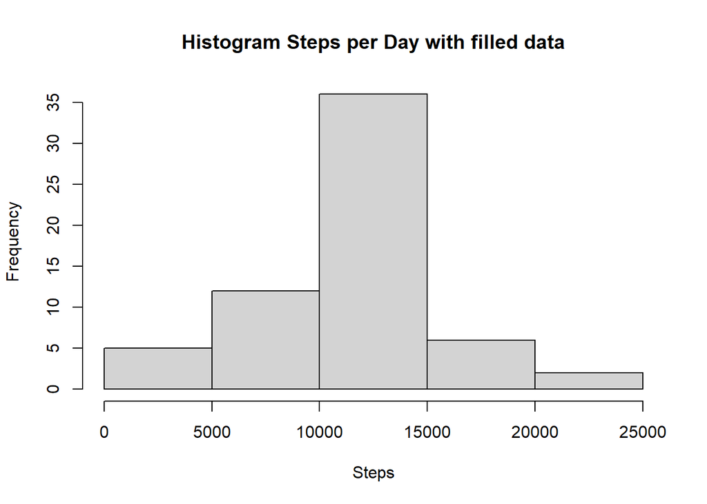

```r
stepFilled <- tapply(actFilled$steps, actFilled$date, sum)
hist(stepFilled, main = "Histogram Steps per Day with filled data",
     xlab = "Steps")
```

### Calculate and report the mean and median total number of steps taken per day

Mean and median number of steps taken each day:

```r
meanFilled <- mean(stepFilled, na.rm = TRUE)
medianFilled <- median(stepFilled, na.rm = TRUE)
```

The mean of steps taken each day is: 1.0766189^{4}  
The median of steps taken each day is: 1.0766189^{4}

### Do these values differ from the estimates from the first part of the assignment?

Mean with NA: 1.0766189^{4}  
Mean without NA: 1.0766189^{4}  
Median with NA: 10765  
Median without NA: 1.0766189^{4}

### What is the impact of imputing data on the estimates of the total daily number of steps?

There is a little difference in the median, but there is almost no impact.

## Are there differences in activity patterns between weekdays and weekends?

For this part the weekdays() function may be of some help here. Use the dataset with the filled-in missing values for this part.

Create a new factor variable in the dataset with two levels – “weekday” and “weekend” indicating whether a given date is a weekday or weekend day.

```r
actFilled$day <- ifelse(weekdays(as.Date(actFilled$date)) == "Saturday" |
                        weekdays(as.Date(actFilled$date)) == "Sunday",
                        "Weekend", "Weekday")
```

Make a panel plot containing a time series plot (i.e. type = “l”) of the 5-minute interval (x-axis) and the average number of steps taken, averaged across all weekday days or weekend days (y-axis).

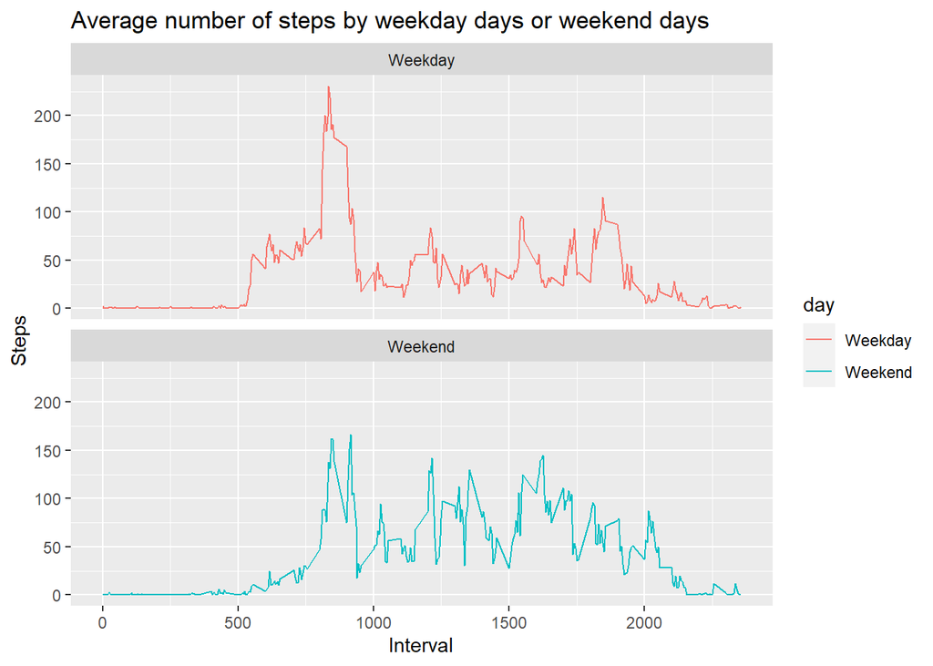

```r
actFilled$day <- as.factor(actFilled$day)

plotData <- actFilled %>%
  group_by(interval, day) %>%
  summarize(steps = mean(steps))
plot <- ggplot(plotData, aes(x = interval, y = steps, color = day)) +
         geom_line() + facet_wrap(~day, ncol = 1, nrow=2) +
         ggtitle("Average number of steps by weekday days or weekend days") +
         xlab("Interval") + ylab("Steps")
print(plot)
```